# Homework 4

## Neal Marquez

2. Use the Lee-Carter method to obtain probabilistic forecasts of mortality in Mexico for 2015-2020. Obtain probabilistic forecasts of the mortality index, kt. Hence find a confidence interval for the age-specific mortality rate, nmx, for women aged 75-80 in 2015-2020.

The Lee Crater parameters were calculated in two seperate ways, once by least squares and another by SVD. The models proced very similiar mean forecasts however gretaly differed in their uncertainty as seen by the standard deviation in the random walk of the $k_t$ terms which were `.0522` & `.3018` for the least squares and SVD methods respectively. If the $b$ values are scaled so that they average one and scale $k$ to the inverse of the same value in the svd model then the standard deviation of the random walk for the svd method becomes $.0557$ and much more similar to the least squares approach. Either way the final estimates and uncertainty end up very similar. The plots for each forecast method are shown against the actual mexico female mortality data in log space below.

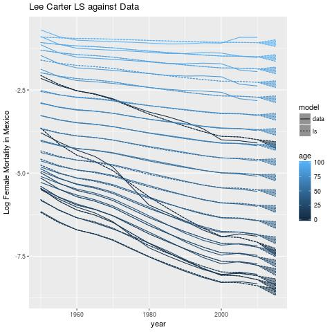

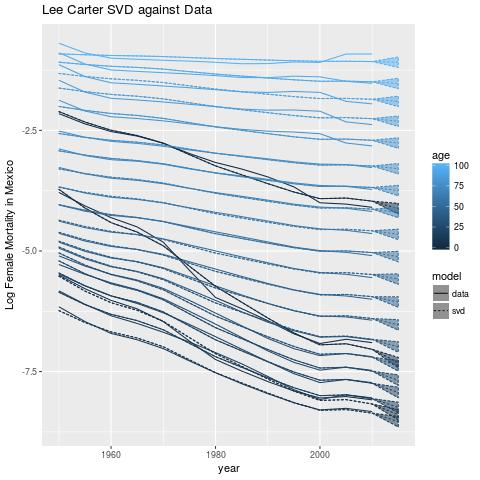

The uncetainty from the random walk model for each age group is shown below for the least squares model fit and the svd model fit respectively where ymin is the 2.5% confidence interval and ymax is the 97.5% confidence interval.

### Least Squares Model fit Estimates and Uncertainty

| lnmxt | age | year | model | ymin | ymax |
| --- | --- | --- | --- | --- | --- |
| -4.154011 | 0 | 2015 | ls | -4.256414 | -4.0516086 |
| -7.366427 | 1 | 2015 | ls | -7.468829 | -7.2640241 |
| -8.436859 | 5 | 2015 | ls | -8.539261 | -8.3344560 |
| -8.574348 | 10 | 2015 | ls | -8.676751 | -8.4719459 |
| -8.281179 | 15 | 2015 | ls | -8.383581 | -8.1787760 |
| -7.970710 | 20 | 2015 | ls | -8.073113 | -7.8683078 |
| -7.716431 | 25 | 2015 | ls | -7.818834 | -7.6140286 |
| -7.415483 | 30 | 2015 | ls | -7.517886 | -7.3130805 |
| -7.022140 | 35 | 2015 | ls | -7.124542 | -6.9197373 |
| -6.559744 | 40 | 2015 | ls | -6.662147 | -6.4573413 |
| -6.080090 | 45 | 2015 | ls | -6.182493 | -5.9776874 |
| -5.600567 | 50 | 2015 | ls | -5.702969 | -5.4981641 |
| -5.132307 | 55 | 2015 | ls | -5.234710 | -5.0299047 |
| -4.671966 | 60 | 2015 | ls | -4.774369 | -4.5695635 |
| -4.217219 | 65 | 2015 | ls | -4.319621 | -4.1148162 |
| -3.760514 | 70 | 2015 | ls | -3.862916 | -3.6581110 |
| -3.306348 | 75 | 2015 | ls | -3.408750 | -3.2039452 |
| -2.778054 | 80 | 2015 | ls | -2.880457 | -2.6756517 |
| -2.324761 | 85 | 2015 | ls | -2.427164 | -2.2223587 |
| -1.912305 | 90 | 2015 | ls | -2.014708 | -1.8099025 |
| -1.537097 | 95 | 2015 | ls | -1.639500 | -1.4346948 |
| -1.090144 | 100 | 2015 | ls | -1.192547 | -0.9877415 |

### SVD Model fit Estimates and Uncertainty

| lnmxt | age | year | model | ymin | ymax |
| --- | --- | --- | --- | --- | --- |
| -4.121788 | 0 | 2015 | svd | -4.230890 | -4.012686 |
| -7.314561 | 1 | 2015 | svd | -7.423663 | -7.205459 |
| -8.393671 | 5 | 2015 | svd | -8.502773 | -8.284569 |
| -8.538055 | 10 | 2015 | svd | -8.647157 | -8.428953 |
| -8.243947 | 15 | 2015 | svd | -8.353049 | -8.134845 |
| -7.932990 | 20 | 2015 | svd | -8.042092 | -7.823888 |
| -7.679733 | 25 | 2015 | svd | -7.788835 | -7.570631 |
| -7.380616 | 30 | 2015 | svd | -7.489718 | -7.271514 |
| -6.990557 | 35 | 2015 | svd | -7.099659 | -6.881455 |
| -6.532980 | 40 | 2015 | svd | -6.642082 | -6.423878 |
| -6.057571 | 45 | 2015 | svd | -6.166673 | -5.948469 |
| -5.581362 | 50 | 2015 | svd | -5.690464 | -5.472260 |
| -5.115113 | 55 | 2015 | svd | -5.224215 | -5.006011 |
| -4.656113 | 60 | 2015 | svd | -4.765215 | -4.547011 |
| -4.202307 | 65 | 2015 | svd | -4.311409 | -4.093205 |
| -3.746838 | 70 | 2015 | svd | -3.855940 | -3.637736 |
| -3.294020 | 75 | 2015 | svd | -3.403122 | -3.184918 |
| -2.762654 | 80 | 2015 | svd | -2.871756 | -2.653552 |
| -2.309824 | 85 | 2015 | svd | -2.418926 | -2.200722 |
| -1.899113 | 90 | 2015 | svd | -2.008215 | -1.790011 |
| -1.526774 | 95 | 2015 | svd | -1.635876 | -1.417672 |
| -1.086289 | 100 | 2015 | svd | -1.195391 | -0.977187 |

3. The purpose of this question is to give you some practice in fitting the simplest form of Bayesian hierarchical model, namely the random intercept model, or Bayesian random effects one-way analysis of variance model. This question uses data from the 1975 U.S. Sustaining Effects Study of elementary education, available as the `egsingle` dataset in the `mlmRev` R package. This gives data on 1,721 students in 60 schools. We will take math (Mathematics achievement score) as the outcome variable, and schoolid (the code for the school the student attends) as the grouping variable. We will use only the data for year 0.5 (for which there are data on 1672 students). Your task is to estimate the Bayesian random effects one-way analysis of variance model for these data and interpret the results.
1. Write out the Bayesian random effects one-way analysis of variance model for these data. What are the unknown parameters to be estimated?

This hierarchical bayesian model will model the mean of all students across all schools, the variance across all students, as well as the variation accounted for by the effect of the schools themselves. These parameters are $\mu_{\alpha}$, $\sigma_{\epsilon}$, and $\sigma_{\alpha}$ respectively. The model will also produce a fit for $\alpha_j$ which are a school specific effects that deviate away from $\mu_{\alpha}$ with a standard deviation of $\sigma_{\alpha}$. The data that this model is fitting is math test scores $y_{i,j}$ where $i$ is the student and $j$ is the school. The functional form of the model is as follows

$$y_{i,j} = \alpha_{j} + \epsilon_{i,j} \\
\epsilon_{i,j} \stackrel{iid}{\sim} \mathcal{N}(0, \sigma^{2}_{\epsilon}) \\
\alpha_{j} \stackrel{iid}{\sim} \mathcal{N}(\mu_{\alpha},\sigma^{2}_{\alpha}) \\$$

2. Specify a reasonable prior distribution for the parameters. Explain your reasoning.

$$\sigma_{y} \sim Uniform(0,100) \\
\sigma_{\alpha} \sim Uniform(0,100) \\
\mu_{\alpha} \sim \mathcal{N}(0,100^2) \\$$

3. Estimate the model in a Bayesian way via Markov chain Monte Carlo.

The model will be estimated using PyMC 3 which uses a Hamiltonian Markov Chain varient of the Markov Chain Monte Carlo Algorithm with a No U-Turn Sampling method. This sampling method is ideal for estimating continuous parameters where information on the first order gradient can be used to inform step size. The parameter start points are selected by estimating the maximum a posteriori (MAP) via automatic differentiation variational inference (ADVI).

4. Assess the convergence of your algorithm & whether it has run for enough iterations.

The model appers to reach converegence as the samples seem to fluctuate at random around a stable value relative to its intil start value. The images below show all 5000 iterations as well as only the last 4500 iterations, where 500 were removed for burn in, to demonstrate this convergence graphically for the parameters we wish to estimate. The iteration number is on the x-axis while the sampling value for that iteration is on the y-axis.

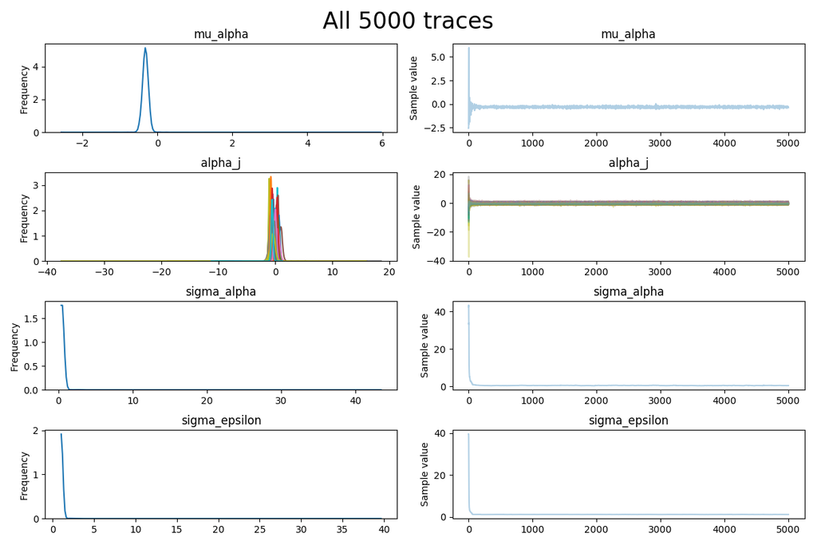

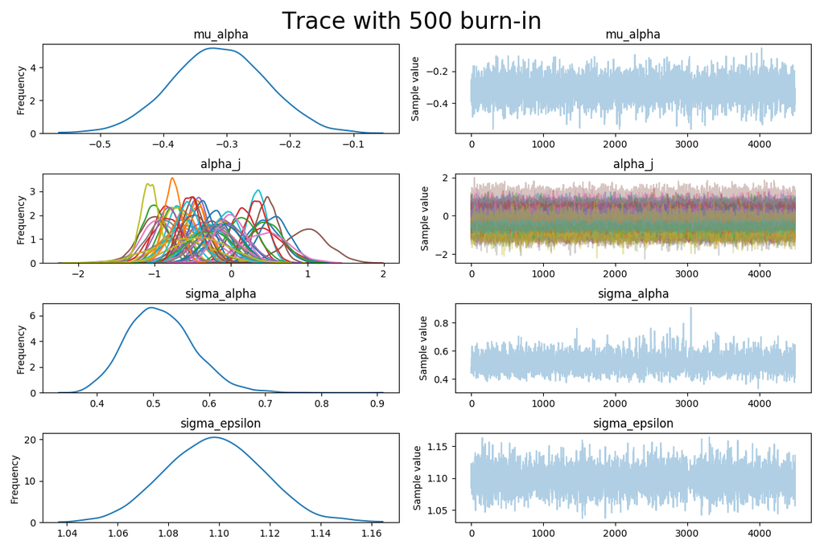

5. Summarize the posterior distribution you obtain in graphical and table form.

The posterior distributions are plotted above for the full set of iterations as well as the set acounting for 500 iterations of burn in. The distributions by in large have a centered mean and appear to be well estimated. Below is a table for the three paramters most of interest and descriptive statitsics of the posterior distribution including the mean, standard deviation, min, max, and the 2.5, 50, & 97.5 quantiles.

[output not shown]

These values are in line with the estimates that are given by estimating a linear mixed effects model via restricted maximum likelihood (REML).

```
 mu_alpha     sigma_alpha   sigma_epsilon
-0.3111669     0.5019289     1.0972490
```

### Code Appendix

#### R

```r
rm(list=ls())
pacman::p_load(pracma, data.table, wpp2015, ggplot2, knitr, bayesPop, mlmRev)

# question 2
data(mxF)
DF <- subset(as.data.table(mxF), country == "Mexico",
             select=c("age", "2005-2010"))
setnames(DF, c("age", "asmr"))
DF$age <- as.numeric(as.character(DF$age))
mxt <- log(as.matrix(subset(mxF, country == "Mexico")[,4:16]))
ax <- apply(mxt, 1, mean)
kt <- apply(mxt - ax, 2, mean)
meanadjxt <- mxt - ax

bx <- apply(meanadjxt, 1, function(x) lm(x ~ 0 + kt)$coefficients[[1]])
nu <- (kt[length(kt)] - kt[1]) / (length(kt) - 1)
sigma_k <- sd(kt[2:length(kt)] - kt[1:(length(kt) -1)])
eps <- sd(mxt - (bx %*% t(kt) + ax))

kt_forecast <- c(kt, kt[length(kt)] + nu)


DFforecast <- data.table(lnmxt=c(bx %*% t(kt_forecast) + ax),
                         age=rep(DF$age, length(kt_forecast)),
                         year=rep(seq(1950, 2015, 5), each=nrow(DF)),
                         model="ls")

DFforecast[,ymin:=lnmxt - 1.96*sigma_k]
DFforecast[year != 2015, ymin:=lnmxt]
DFforecast[,ymax:=lnmxt + 1.96*sigma_k]
DFforecast[year != 2015, ymax:=lnmxt]

jpeg('~/Documents/Classes/statdemog/week5/lsleecarter.jpg')
ggplot(DFforecast, aes(x=year, y=lnmxt, color=age, group=age)) + geom_line() +
    geom_ribbon(aes(ymin=ymin, ymax=ymax, fill=age), alpha=.5) +
    labs(title="LS Lee-Carter")
dev.off()


lm.t.x <- t(mxt)
Y <- sweep(lm.t.x, 2, ax)             #mean centered data
Y.svd <- svd(Y)                       #returns U %*% diag(d) %*% t(V) = Y
bxsvd <- Y.svd$v[,1]
b1sign <- sign(bxsvd[1])
ktsvd <- Y.svd$d[1]*Y.svd$u[,1]
bxsvd <- bxsvd*b1sign
ktsvd <- ktsvd*b1sign
scalefactor <- length(bxsvd) / sum(bxsvd)
ktsvd <- ktsvd / scalefactor
bxsvd <- bxsvd * scalefactor
nusvd <- (ktsvd[length(ktsvd)] - ktsvd[1]) / (length(ktsvd) - 1)
sigma_ksvd <- sd(ktsvd[2:length(ktsvd)] - ktsvd[1:(length(ktsvd) -1)])
ktsvd_forecast <- c(ktsvd, ktsvd[length(ktsvd)] + nusvd)
epssvd <- sd(mxt - (bxsvd %*% t(ktsvd) + ax))


DFforecastsvd <- data.table(lnmxt=c(bxsvd %*% t(ktsvd_forecast) + ax),
                            age=rep(DF$age, length(ktsvd_forecast)),
                            year=rep(seq(1950, 2015, 5), each=nrow(DF)),
                            model="svd")

DFforecastsvd[,ymin:=lnmxt - 1.96*sigma_ksvd]
DFforecastsvd[year != 2015, ymin:=lnmxt]
DFforecastsvd[,ymax:=lnmxt + 1.96*sigma_ksvd]
DFforecastsvd[year != 2015, ymax:=lnmxt]

jpeg('~/Documents/Classes/statdemog/week5/svdleecarter.jpg')
ggplot(DFforecastsvd, aes(x=year, y=lnmxt, color=age, group=age)) + geom_line() +
    geom_ribbon(aes(ymin=ymin, ymax=ymax, fill=age), alpha=.5) +
    labs(title="SVD Lee Carter")
dev.off()

DFobs <- data.table(lnmxt=c(mxt), age=rep(DF$age, length(ktsvd)),
                    year=rep(seq(1950, 2010, 5), each=nrow(DF)), model="data",
                    ymin=NA, ymax=NA)
ggplot(DFobs, aes(x=year, y=lnmxt, color=age, group=age)) + geom_line()

DFfff <- rbindlist(list(DFobs, DFforecast))

jpeg('~/Documents/Classes/statdemog/week5/allleecarterls.jpg')
ggplot(DFfff, aes(x=year, y=lnmxt, color=age,
                  group=interaction(age, model), linetype=model)) +
    geom_line() + geom_ribbon(aes(ymin=ymin, ymax=ymax, fill=age), alpha=.5) +
    labs(title="Lee Carter LS against Data", y="Log Female Mortality in Mexico")
dev.off()

DFfff2 <- rbindlist(list(DFobs, DFforecastsvd))

jpeg('~/Documents/Classes/statdemog/week5/allleecartersvd.jpg')
ggplot(DFfff2, aes(x=year, y=lnmxt, color=age,
                   group=interaction(age, model), linetype=model)) +
    geom_line() + geom_ribbon(aes(ymin=ymin, ymax=ymax, fill=age), alpha=.5) +
    labs(title="Lee Carter SVD against Data", y="Log Female Mortality in Mexico")
dev.off()


jpeg('~/Documents/Classes/statdemog/week5/allleecarter75.jpg')
ggplot(subset(DFfff, age == 75), aes(x=year, y=lnmxt, color=age,
                                     group=interaction(age, model), linetype=model)) +
    geom_line() + geom_ribbon(aes(ymin=ymin, ymax=ymax, fill=age), alpha=.5) +
    labs(title="Lee Carter Compare")
dev.off()

kable(subset(DFfff, year == 2015), format="markdown")
kable(subset(DFfff2, year == 2015), format="markdown")


# question 3
mlm <- lmer(math ~ 1 + (1|schoolid), data=subset(egsingle, year==.5))
mlm@beta

params <- c(mlm@beta, as.data.frame(summary(mlm)$varcor)$sdcor)
names(params) <- c("mu_alpha", "sigma_alpha", "sigma_epsilon")
params

sd(summary(subset(egsingle, year==.5)$math))
```

#### Python

```python
import pymc3 as pm
import pandas as pd
import numpy as np
import matplotlib.pyplot as plt

DF = pd.read_csv("/home/nmarquez/Documents/Classes/statdemog/week5/school.csv")
DF = DF.query("year == .5")[["schoolid", "math"]]
DF["schoolfactor"] = pd.factorize(DF["schoolid"])[0]
J = len(np.unique(DF.schoolfactor))
N = DF.shape[0]


with pm.Model() as BYHM:
    mu_alpha = pm.Normal("mu_alpha", mu=0, sd=100.)
    sigma_alpha = pm.Uniform("sigma_alpha", lower=0., upper=100.)
    sigma_epsilon = pm.Uniform("sigma_epsilon", lower=0., upper=100.)

    alpha_j = pm.Normal("alpha_j", mu_alpha, sd=sigma_alpha, shape=J)

    mathhat = alpha_j[DF.schoolfactor.values]

    ylike = pm.Normal("ylike", mu=mathhat, sd=sigma_epsilon,
                      observed=DF.math.values)

with BYHM:
    step = pm.NUTS()
    trace = pm.sample(5000, step=step)

pm.traceplot(trace[0:])
plt.suptitle("All 5000 traces", fontsize=24, y=.98)
plt.subplots_adjust(top=0.92)
plt.savefig('/home/nmarquez/Documents/Classes/statdemog/week5/alltrace.png')
with BYHM:
    # Use ADVI for initialization
    mu, sds, elbo = pm.variational.advi(n=100000)
    step = pm.NUTS(scaling=BYHM.dict_to_array(sds)**2, is_cov=True)
    ht = pm.sample(5000, step, start=mu)

burn = 500
pm.traceplot(ht[burn:])
plt.suptitle("Trace with 500 burn-in", fontsize=24, y=.98)
plt.subplots_adjust(top=0.92)
plt.savefig('/home/nmarquez/Documents/Classes/statdemog/week5/burntrace.png')

params = ["mu_alpha", "sigma_alpha", "sigma_epsilon"]
perc = [.025, .5, .975]
desc = pd.DataFrame({k: pd.Series(ht[k][burn:]).describe(percentiles=perc)[1:]
                     for k in params})
desc
```